# R Notebook

```r
rm(list = ls())
library(ISLR)
library(pls)
set.seed(2)
x = model.matrix(Salary~., Hitters)[,-1]
y = Hitters$Salary
y<-na.omit(y)
train = sample(1:nrow(x), nrow(x)/2)
test = (-train)
y.test=y[test]
```

This is the set up for the modeling. We want to get rid of the na values first, and then we will set up the testing and training data.

```r
pcr.fit = pcr(Salary ~., data = Hitters, scale=T, validation='CV')
summary(pcr.fit)
```

```
## Data:    X dimension: 263 19
##  Y dimension: 263 1
## Fit method: svdpc
## Number of components considered: 19
##
## VALIDATION: RMSEP
## Cross-validated using 10 random segments.
##        (Intercept)  1 comps  2 comps  3 comps  4 comps  5 comps  6 comps
## CV             452    352.7    351.3    350.9    348.2    345.0    342.9
## adjCV          452    352.3    350.9    350.5    347.8    344.5    342.1
##        7 comps  8 comps  9 comps  10 comps  11 comps  12 comps  13 comps
## CV       343.8    345.1    349.0     347.0     349.4     349.9     349.7
## adjCV    343.0    344.2    347.9     345.9     348.1     348.6     348.4
##        14 comps  15 comps  16 comps  17 comps  18 comps  19 comps
## CV        344.4     344.1     337.8     337.4     334.6     339.2
## adjCV     342.7     342.6     336.2     335.7     332.9     337.3
##
## TRAINING: % variance explained
##         1 comps  2 comps  3 comps  4 comps  5 comps  6 comps  7 comps  8 comps
## X         38.31    60.16    70.84    79.03    84.29    88.63    92.26    94.96
## Salary    40.63    41.58    42.17    43.22    44.90    46.48    46.69    46.75
##         9 comps  10 comps  11 comps  12 comps  13 comps  14 comps  15 comps
## X         96.28     97.26     97.98     98.65     99.15     99.47     99.75
## Salary    46.86     47.76     47.82     47.85     48.10     50.40     50.55
##         16 comps  17 comps  18 comps  19 comps
## X          99.89     99.97     99.99    100.00
## Salary     53.01     53.85     54.61     54.61
```

validation=“CV” causes pcr() to compute the ten-fold cross-validation error for each possible value of M, the number of principal components used. The resulting fit can be examined using summary().

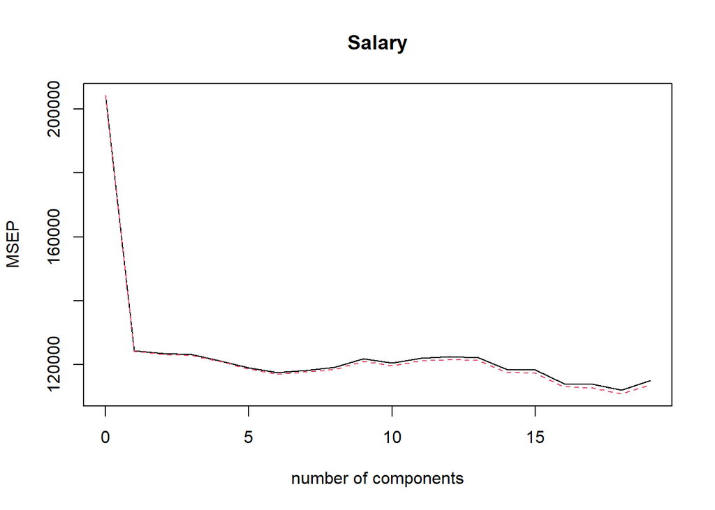

```r
validationplot(pcr.fit, val.type = "MSEP")
```

plot the cross-validation scores using the validationplot() function. Using val.type=“MSEP” will cause the cross-validation MSE to be plotted. We see that the smallest cross-validation error occurs when M = 18 components are used. This is barely fewer than M = 19, which amounts to simply performing least squares, because when all of the components are used in PCR no dimension reduction occurs. cross-validation error is roughly the same when only one component is included in the model. This suggests that a model that uses just a small number of components might suffice Briefly, we can think of this as the amount of information about the predictors or the response that is captured using M principal components. For example, setting M = 1 only captures 38.31% of all the variance, or information, in the predictors. In contrast, using M = 6 increases the value to 88.63%. If we were to use all M = p = 19 components, this would increase to 100%.

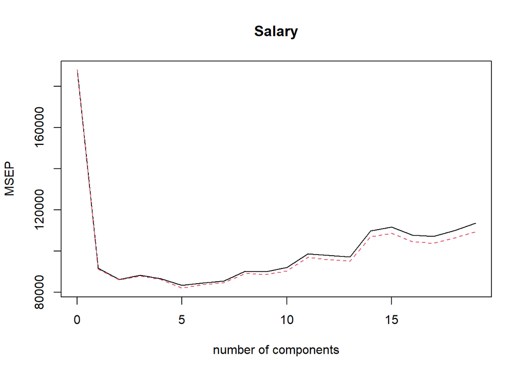

```r
set.seed(1)
pcr.fit=pcr(Salary~., data=Hitters ,subset =train ,scale =TRUE ,
            validation ="CV")
validationplot(pcr.fit, val.type = "MSEP")
```

Now we find that the lowest cross-validation error occurs when M = 5 component are used. We compute the test MSE as follows

```r
pcr.pred = predict(pcr.fit, x[test,],ncomp = 5)
mean((pcr.pred -y.test)^2)
```

```
## [1] 105186.7
```

```r
pcr.fit=pcr(y~x,scale =TRUE ,ncomp =5)
summary(pcr.fit)
```

```
## Data:    X dimension: 263 19
##  Y dimension: 263 1
## Fit method: svdpc
## Number of components considered: 5
## TRAINING: % variance explained
##    1 comps  2 comps  3 comps  4 comps  5 comps
## X    38.31    60.16    70.84    79.03    84.29
## y    40.63    41.58    42.17    43.22    44.90
```

Finally, we fit PCR on the full data set, using M = 5, the number of components identified by cross-validation

```r
set.seed(1)
pls.fit = plsr(Salary~., data=Hitters, subset=train, scale=T, validation='CV')
summary(pls.fit)
```

```
## Data:    X dimension: 108 19
##  Y dimension: 108 1
## Fit method: kernelpls
## Number of components considered: 19
##
## VALIDATION: RMSEP
## Cross-validated using 10 random segments.
##        (Intercept)  1 comps  2 comps  3 comps  4 comps  5 comps  6 comps
## CV           433.6    293.3      293    298.0    307.0    323.9    325.3
## adjCV        433.6    292.8      292    296.3    304.4    319.4    321.0
##        7 comps  8 comps  9 comps  10 comps  11 comps  12 comps  13 comps
## CV       319.8    326.0    331.9     331.7     332.2     334.6     327.2
## adjCV    315.7    321.4    326.5     326.1     326.5     328.7     322.0
##        14 comps  15 comps  16 comps  17 comps  18 comps  19 comps
## CV        327.5     331.9     331.8     334.7     336.3     336.8
## adjCV     322.3     326.3     326.2     328.9     330.3     330.8
##
## TRAINING: % variance explained
##         1 comps  2 comps  3 comps  4 comps  5 comps  6 comps  7 comps  8 comps
## X         38.98    57.16    67.33    72.30    77.48    86.03    88.59    90.88
## Salary    57.33    61.20    63.82    65.58    67.10    67.59    68.37    69.37
##         9 comps  10 comps  11 comps  12 comps  13 comps  14 comps  15 comps
## X         93.82     95.05     96.99     97.67     98.19     98.76     99.00
## Salary    69.98     70.67     70.90     71.05     71.15     71.19     71.25
##         16 comps  17 comps  18 comps  19 comps
## X          99.71     99.89     100.0    100.00
## Salary     71.26     71.28      71.3     71.31
```

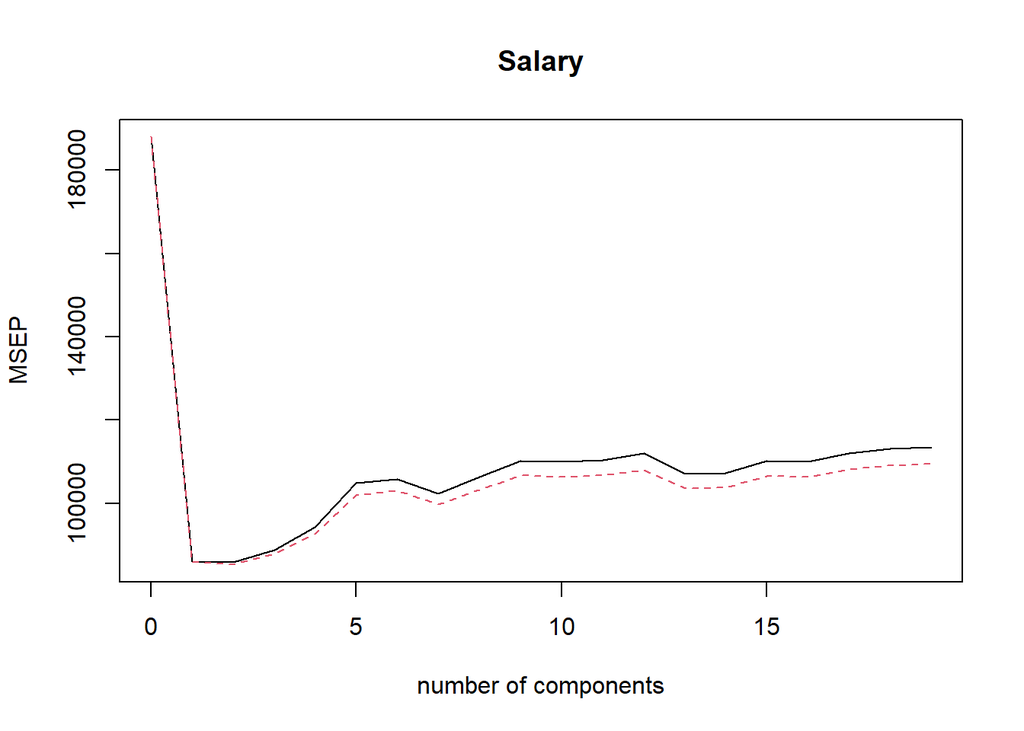

```r
validationplot(pls.fit , val.type="MSEP")
```

```r
pls.pred = predict(pls.fit, x[test,], ncomp = 1)
mean((pls.pred-y.test)^2)
```

```
## [1] 101088.4
```

The test MSE is comparable to, but slightly less than, the test MSE obtained using PCR.

```r
pls.fit=plsr(Salary~., data=Hitters ,scale=TRUE ,ncomp =1)
summary(pls.fit)
```

```
## Data:    X dimension: 263 19
##  Y dimension: 263 1
## Fit method: kernelpls
## Number of components considered: 1
## TRAINING: % variance explained
##         1 comps
## X         38.08
## Salary    43.05
```

```r
rm(list=ls())
library(caret)
library(ISLR)
data("Hitters")
set.seed(2)
sum(is.na(Hitters))
```

```
## [1] 59
```

```r
Hitters<- na.omit(Hitters)
```

We are removing any NA’s to clean up our data

```r
dividedata <- createDataPartition(Hitters$Salary, p=0.8, list = F)
train <- Hitters[dividedata,]
test <- Hitters[-dividedata,]
```

Here we are setting up our training and testing data using the createDataPartition command in the Caret package

```r
pcr.fit <- train(Salary~., method="pcr", data=train, scale=T, trControl = trainControl('cv', number=10), tuneLength=19)
```

An additional argument is scale = TRUE for standardizing the variables to make them comparable.

Caret uses cross-validation to automatically identify the optimal number of principal components (ncomp) to be incorporated in the model.

```r
summary(pcr.fit$finalModel)
```

```
## Data:    X dimension: 212 19
##  Y dimension: 212 1
## Fit method: svdpc
## Number of components considered: 5
## TRAINING: % variance explained
##           1 comps  2 comps  3 comps  4 comps  5 comps
## X           37.69    60.08    71.19    79.08    84.37
## .outcome    34.15    36.30    37.25    37.89    39.95
```

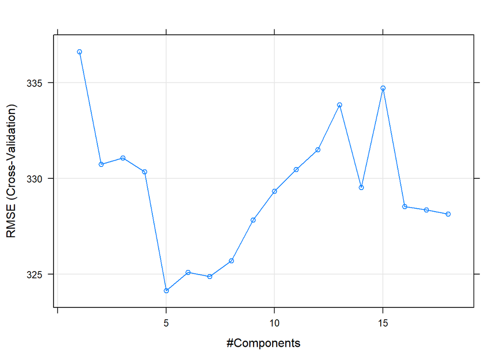

```r
plot(pcr.fit)
```

```r
pcr.fit$bestTune
```

|  | ncomp |
| --- | --- |
| 5 | 5 |

Here we are looking for the number of components that reduces our RMSE and it is 5. The bestTune tells us that 5 principal components is the optimal amount.

```r
newpred <- predict(pcr.fit, newdata = test)
data.frame(
  MSE = (caret::RMSE(newpred, test$Salary)^2),
  Rsquare = caret::R2(newpred, test$Salary)
)
```

| MSE | Rsquare |
| --- | --- |
| 136778.4 | 0.6037051 |

The MSE is higher than before when using the lab model

We will now do the same process for the Partial Least Squares method

```r
set.seed(1)
pls.fit <- train(Salary~., data=train, method='pls', scale=T, trControl = trainControl('cv', number = 10), tuneLength = 19)
```

We use the same notation as the pcr.fit model with the only change being “method = ‘pls’” now

```r
summary(pls.fit$finalModel)
```

```
## Data:    X dimension: 212 19
##  Y dimension: 212 1
## Fit method: oscorespls
## Number of components considered: 10
## TRAINING: % variance explained
##           1 comps  2 comps  3 comps  4 comps  5 comps  6 comps  7 comps
## X           37.22    53.61    66.48    74.91    79.46    84.32    87.87
## .outcome    37.61    40.47    42.04    42.93    44.66    46.19    47.31
##           8 comps  9 comps  10 comps
## X           90.32    92.72     95.05
## .outcome    48.15    48.64     48.98
```

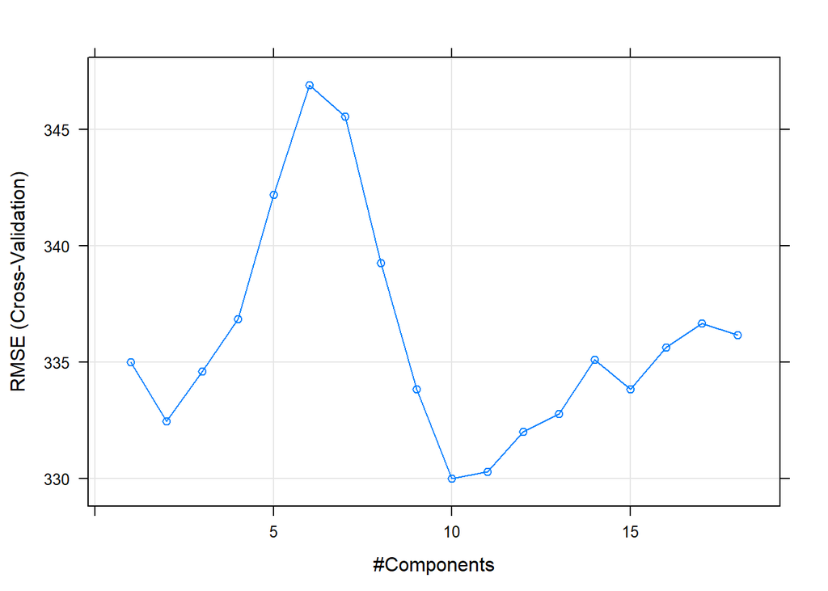

```r
plot(pls.fit)
```

```r
pls.fit$bestTune
```

|  | ncomp |
| --- | --- |
| 10 | 10 |

Here we can see that the best amount of components in this case to reduce the MSE is 10 This model explains 49% of the variance in salary using 10 components

```r
predictions <- predict(pls.fit, newdata = test)
data.frame(
  MSE = (caret::RMSE(predictions, test$Salary)^2),
  Rsquare = caret::R2(predictions, test$Salary)
)
```

| MSE | Rsquare |
| --- | --- |
| 115752.6 | 0.6281921 |

The MSE in the PLS method is slightly lower than the PCR model using the Caret package.  
Notice that the percentage of variance in Salary that the ten-component PLS fit explains, 48.98%, is more than what was explained using the final five-component model PCR fit, 39.95 %. This is because PCR only attempts to maximize the amount of variance explained in the predictors, while PLS searches for directions that explain variance in both the predictors and the response